# R Notebook

Time Series Forecasting :- A time series is a list of numbers along with the information about at what time the information was recorded.

```r
# defining a time series
y = ts(c(123,74,88,34), start = 2012)
y
```

```
Time Series:
Start = 2012
End = 2015
Frequency = 1
[1] 123  74  88  34
```

Frequency :- number of observations before the seasonal pattern repeats.

```r
# defining a time series with frequency more than 1
y = ts(runif(36,50,100), start = 2012, frequency = 12)
# Frequency = 12 -> Monthly data
# Frequency = 4 -> Quarterly data
# Frequency = 52 -> Weekly data
# Frequency = 1 -> Annual data
y
```

```
          Jan      Feb      Mar      Apr      May      Jun      Jul      Aug      Sep      Oct      Nov      Dec
2012 97.21065 69.64123 68.16275 65.72687 64.88251 62.31411 97.37136 94.13365 64.48506 78.10728 75.87194 94.54482
2013 53.74235 73.87685 69.13449 63.42162 61.35169 94.37257 97.49104 53.18571 53.58086 97.75685 83.49069 70.30487
2014 82.72169 66.05735 95.78260 74.94265 99.25124 98.67068 73.15769 92.99046 63.33119 85.21422 81.67910 56.29820
```

Time Plots :- For time series data, most useful graph to start with is a time plot. We will now look at a plot from Weekly Economy passenger load on Ansett Airlines “melsyd”

autoplot command helps in plotting time series data from Economy class variable.

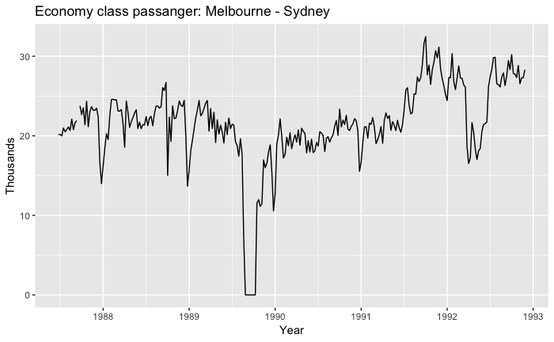

```r
autoplot(melsyd[,"Economy.Class"]) +
  ggtitle("Economy class passanger: Melbourne - Sydney") +
  xlab("Year") +
  ylab("Thousands")
```

Lernings :- 1. There was a period in 1989 when no passanger was carried. 2. There was a period in 1992 when the load was low. 3. There was a increase in load in 2nd half of 1991. 4. There is a dip in load at the start of each year. 5. There is a long term fluctuation in level of the series which increases in 1987, decrease in 1989 and then increase in 1991.

Now let’s look at a simpler time series Monthly Scripts of pharmaceutical products

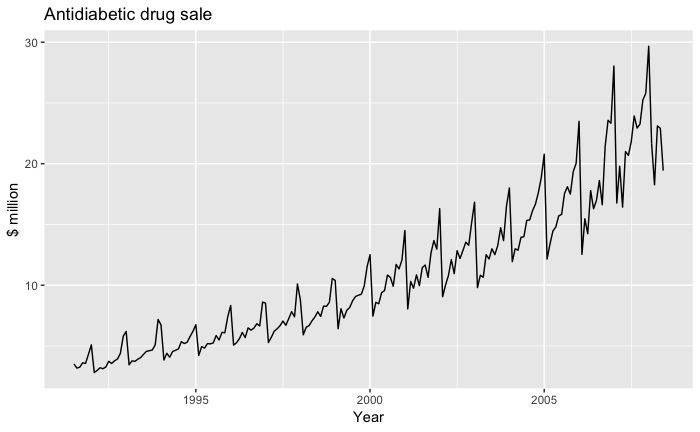

```r
autoplot(a10) +
  ggtitle("Antidiabetic drug sale") +
  ylab("$ million") +
  xlab("Year")
```

Learning:- 1. There is an increasing trend. 2. Seasonal patterns that increase in size as the level increases.

Time Series Patterns :- 1. Trend :- Trend are the long term increase or decrease in the data. Trend might also change direction within the time series which means it goes from increasing trend to decreasing trend. 2. Seasonal :- A seasonal pattern occurs when a time series is affected by seasonal factors i.e. time of the year, day of the week. Seasonality has a fixed and known frequency. 3. Cyclic :- A cycle occurs when the data exhibits rises and fall that are not of a fixed frequency.

The length of cycles are more than length of seasons usually and the magnitude of cycles tend to be more variable than magnitude of seasonal patterns.

```r
par(mfrow = c(2,2))
plot(elec, xlab = "year", ylab = "Australian Monthly electricity production")
plot(ustreas, xlab = "time", ylab = "US treasury bill contracts")
```

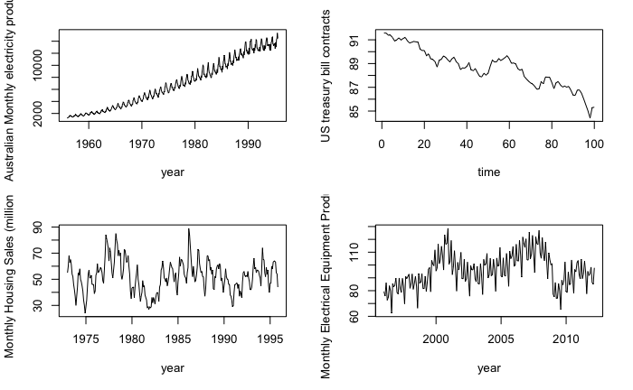

```r
plot(hsales, xlab = "year", ylab = "Monthly Housing Sales (millions)")
plot(elecequip, xlab = "year", ylab = "Monthly Electrical Equipment Production")
```

Seasonal Plots ####################################################################################################

Seasonal Plots are similar to time plots except that the data are plotted against the individual seasons.

Seasonal plots for the antidiabetic drugs sales

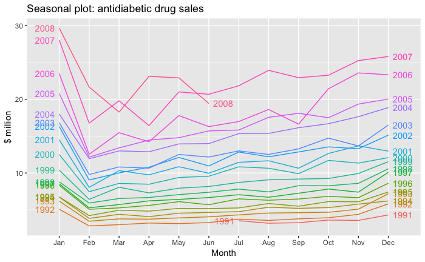

```r
ggseasonplot(a10, year.labels = TRUE, year.labels.left = TRUE) +
  ggtitle("Seasonal plot: antidiabetic drug sales") +
  ylab("$ million")
```

Seasonal plots helps in looking at seasonality more clearly, and is useful in identifying the years in which pattern has changed.

Learning from above plot:- 1. A big jump in sales in month of January. 2. March 2008 sales has negative slope opposite of other years. 3. Sales pattern in month of april is not consistent.

We can also use polar coordinates for the above plot

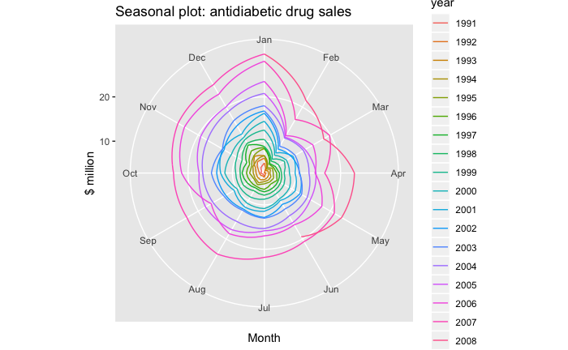

```r
ggseasonplot(a10, polar = TRUE) +
  ggtitle("Seasonal plot: antidiabetic drug sales") +
  ylab("$ million")
```

Seasonal Subseries Plots #################################################################################################### These charts represents data for each season in seperate mini time plots.

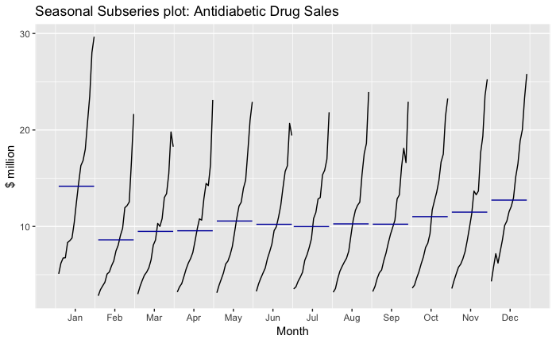

```r
ggsubseriesplot(a10) +
  ylab("$ million") +
  ggtitle("Seasonal Subseries plot: Antidiabetic Drug Sales")
```

The horizontal lines represents the average for each month. This plot can pe used in identifying changes within a season.